# tmpobsd8vq7

## 思想剧场：心里的“对错导航仪”坏了？

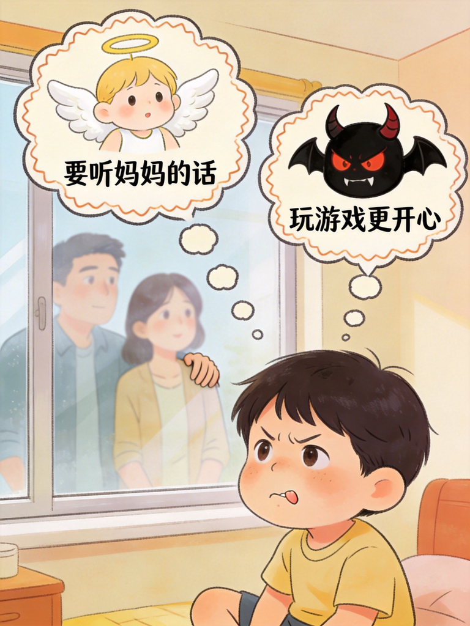

## 第一站：心即理——理不在外面，在心里

[figure not shown]

## 第二站：知行合一——真知道就一定能做到？

[figure not shown]

## 第三站：全球望远镜——中西方的“心”对话

[figure not shown]

# 第十章：王阳明的“心里种花”——良知在你心里 **时间**：现代，期中考试周  
**地点**：阳光小学五年级教室  
**人物**：  
- **小诚**（11岁，班长，成绩优秀但最近压力很大）  
- **小真**（10岁，小诚的好朋友，观察敏锐）  
- **小勇**（11岁，体育委员，直率敢言）  
- **王老师**（新来的道德与法治课老师，总爱讲有趣的故事） — ### 第一幕：考试前的“心跳加速” 【场景】  
期中数学考试前一天，小诚在教室里复习。他发现自己有一道应用题怎么都解不出来，而这道题占15分。如果做不出来，他可能保不住全班第一的位置。 **小真**：（凑过来）小诚，你脸色不太好，这道题很难吗？ **小诚**：（叹气）嗯，我看了三遍例题还是不懂。明天要是考这道题就完了。 **小勇**：（走过来）怕什么！我听说隔壁班有人搞到了“重点题”，你要不要看看？ **小诚**：（一愣）重点题？那不是…… **小勇**：就是可能考的题呗。又不是答案，就是题型相似，看了也不算作弊吧？ **小真**：（皱眉）但是老师说过不能私下传题啊。而且，如果看了，就算考得好也不是真本事。 **小诚**：（内心挣扎）我……我不知道该不该看。心里好像有两个声音在吵架：一个说“就看一眼，为了保住第一名”，另一个说“不行，这是不对的”。 **小勇**：（耸肩）随便你。不过我可听说好几个人都看了。 **小诚**看着手机里同学发来的“重点题”文件，手指悬在打开按钮上，心跳越来越快。 **小真**：（轻声）小诚，你记得王老师上星期说的吗？她说每个人心里都有一个“对错导航仪”，关键时候会告诉你方向。 **小诚**：可是现在我的导航仪好像坏了！两个声音都在响，我听不清哪个是对的。 **小勇**：（点头）我懂这种感觉！上周我偷偷把弟弟的乐高藏起来，明明知道他会哭，但就是不想让他玩我的新套装。后来看到他哭得那么伤心，我心里特别难受，最后还是拿出来了。 这时，王老师拿着几本书走进教室，看见三个孩子围在一起表情严肃。 **王老师**：怎么了孩子们？考试压力太大了吗？ **小诚**：（犹豫了一下）王老师，我有一个问题……如果一个人心里有两个声音，一个想做好事，一个想做“不太好”的事，该怎么知道哪个才是真正的自己？ **王老师**：（眼睛一亮）啊，这个问题问得太好了！五百年前，有一位叫王阳明的先生，也在思考同样的问题。而且他找到了答案——答案就在你心里，像一颗等待发芽的花种。 **小勇**：（怀疑）心里种花？老师您在讲童话吗？ **王老师**：不，我在讲**心学**。想不想听听王阳明的“心里种花”是怎么回事？ **小诚**：（点头）想！ **小真**：（举手）老师，您说的“心里种花”和朱熹爷爷的“宇宙大房子”有什么不一样？ **小勇**：（挑战）如果答案真的在心里，那为什么我们还会做错事？直接听心里的话不就行了？ **王老师**：（微笑）问得好！这正是我们今天要探险的哲学迷宫。准备好了吗？我们的第一站是——🌟**心即理**。 — ## 跨时空对话：小探险家遇见王阳明 **王老师**：在我们开始第一站前，我想带你们玩一个特别的游戏——**心灵时光机**。闭上眼睛，想象你穿越到1510年，来到了王阳明先生讲学的书院。 （孩子们闭上眼睛） **王老师**：现在，你看到了一位穿着长袍、目光温和的先生。他就是王阳明。他微笑着问你一个问题： **王阳明（想象中）**：小朋友，如果你明知道作弊能拿到第一名，但心里有个声音说“这是不对的”，你会听哪个声音？ **小诚**：（睁开眼睛）我……我想听心里那个说“不对”的声音，但说实话，有时候真的很难。 **小真**：我会问自己：如果靠作弊拿了第一，我真的会开心吗？还是反而更难受？ **小勇**：我觉得要看情况……如果大家都作弊，我不作弊不就亏了？ **王老师**：很好的真实想法！现在，让我们听听王阳明会怎么回答。他可能会说： **王阳明（想象中）**：孩子，你心里那个“不对”的声音，就是**良知**。它像一颗花种，本来就长在你心里。私欲的噪音（比如“大家都作弊”）就像杂草，会遮住花种的阳光。**致良知**就是每天除草、浇水，让花种自然生长。 **现在，轮到你的立场选择**： 1. **如果选择听从良知**：你可能暂时失去第一名，但会得到内心的踏实。你会怎么向同学解释你的选择？

2. **如果选择听从私欲**：你可能拿到第一名，但会一直担心被揭穿，内心不安。你准备如何面对这种不安？ （请在心里做出选择，并思考理由。没有标准答案，重要的是你开始觉察内心的两个声音。） — ### 🌟 核心概念：心即理 > **儿童比喻**：**内心自带的道德GPS**。不用外找地图，你心里就有判断是非对错的导航系统。 **王老师讲故事**： “王阳明年轻时也到处寻找‘理’——他读遍古书，拜访名师，甚至学朱熹‘格物致知’，盯着竹子看了七天七夜，结果病倒了也没‘格’出竹子的理是什么。 后来他明白了：我找错地方了！**理不在心外**。就像小诚你刚才的困惑——该不该看‘重点题’，答案不在老师的规定里，不在同学的劝说里，而在你**心里那个第一反应**里。 当你第一眼看到文件时，心里那个‘咯噔’一下的感觉，就是良知在说：‘这不太对’。后面那些‘就看一眼’‘为了第一名’的想法，是**私欲**的噪音干扰了GPS信号。” **小诚**：（若有所思）所以……我的心其实知道答案，只是被其他声音盖住了？ **王老师**：没错！这就是‘心即理’的核心——**道德的真理不在外面，就在你心里**。不需要向外求‘什么是对的’，只需要向内听‘我心里觉得什么是对的’。 ### 思想实验：如果理在心里…… **实验1**：闭上眼睛，想象你捡到一个钱包，里面有一千元。你心里第一个念头是什么？
- A. 交给老师/警察
- B. 自己留下
- C. 不知道 **小真**：我选A！但是……如果选了A，是因为老师教过要拾金不昧，还是我心里真的觉得该这样？ **王老师**：问得深！这就是关键——老师教的是**外部规则**，而你心里的倾向是**内在良知**。当两者一致时，说明外部规则符合你的良知；当冲突时（比如‘大家都作弊，我也可以’），良知会让你不安。 **实验2**：假设世界上没有‘考试不能作弊’这条规则，你作弊时还会不安吗？ **小勇**：可能会轻松一点？但……好像还是会有点不舒服。 **王老师**：这就是良知的证据！它不依赖外部规则存在。就像火会烫手，不管有没有‘小心烫伤’的警示牌，摸了都会疼。 ### 📍 插画指引1：“心里的道德GPS”
- **位置**：本章第一节标题下方
- **视觉描述**：画一个孩子半身像，胸口处有一个发光的导航仪屏幕，屏幕上显示两个箭头：一个箭头标着“良知”，指向“诚实”；另一个箭头标着“私欲”，指向“作弊”。孩子表情困惑，手指在屏幕上犹豫。背景简约，突出胸口的导航仪。

## **寓意**：直观展现内心道德抉择的冲突。

### 🌟 核心概念：知行合一

- > **儿童比喻**：**知道火烫手就不摸**。真知道火烫，自然就不会摸；如果还摸，说明并不是真知道火烫。 **王老师继续**： “小诚，你说你知道‘不该看重点题’，但为什么还是想点开？王阳明会说：那是因为你并不是**真知道**。 真知和行动是一体的，就像硬币的两面。你不可能‘真的知道火烫手’还去摸火；如果摸了，只说明你并不知道‘烫’的真正含义——你只是听说过‘火烫’这个词而已。” **小勇**：（不服）那按这么说，世界上就没有‘知道但做不到’的事了？那我明明知道该早起，为什么还是赖床？ **王老师**：经典问题！王阳明有个学生也问过类似的话。学生说：‘我知道要孝顺父母，但有时还是会对他们不耐烦，怎么办？’ 王阳明回答：‘那不是真知。真知孝顺的人，自然就会体贴父母，不需要勉强自己。’ **小诚**：那怎么才能从‘假知’变成‘真知’？ **王老师**：通过**事上磨练**——在具体事情上练习。 ### 三层“知行合一”对照表 | 层次 | 特征 | 例子 | 如何提升 | |——|——|——|———-| | **假知** | 知道概念，但做不到 | 知道要早起，仍赖床 | 体验后果：迟到一次，感受匆忙和批评 | | **知行合一** | 真知自然导致行动 | 怕烫→不摸火 | 已达标，保持觉察 | | **真知** | 行动本身就是知的证明 | 爱父母→自然体贴 | 内化成本能，无需思考 | **小真**：（记录）所以我们要像训练肌肉一样训练‘真知’？ **王老师**：对！王阳明说‘知行工夫本不可离’，就像学游泳——光看书不上水，永远学不会；跳下水扑腾，才能真正‘知道’游泳是什么。 ### 互动练习：你的“知行合一”检测站
1. **选一个你的‘知道但做不到’**（如：不吃零食、不打游戏超时）
2. **问三重问题**：
   - 我‘知道’的是概念，还是真实感受？（如：我知道零食不健康 vs 我体验过吃太多零食肚子疼）
   - 如果立刻行动，最大的阻碍是什么？
   - 如果做到一次，我会有什么感觉？
3. **设计一次‘真知体验’**（如：允许自己吃一次过量零食，感受不适） **小勇**：那我选‘不打游戏超时’。其实……上周我打到半夜，第二天上课困得不行，那种难受我现在还记得。 **王老师**：这就是‘真知’的种子！下次想超时时，回忆那种困倦难受的感觉——**真知会让你自然放下手机**。 ### 📍 插画指引2：“知行合一”的硬币
- **位置**：本节中段，三层对照表上方
- **视觉描述**：一枚巨大的硬币悬在空中，一面刻着“知”（书本图案），另一面刻着“行”（跑步的小人图案）。硬币正在旋转，两面交替可见，但本质是同一枚硬币。下方一个孩子伸手想触摸，又缩回手。

## **寓意**：知与行是一体两面，不可分割。

### 📍 插画指引3：“全球望远镜”观测站

- **位置**：本章第三站标题下方
- 【视觉建议】视觉描述：一个孩子站在地球仪旁，举着一个巨大的望远镜。望远镜里投射出三个分屏：左边是朱熹在观察竹子，中间是王阳明在静坐，右边是笛卡尔在书桌前思考。孩子头上冒出思考气泡：“原来大家都在问问题！”
- **寓意**：中西哲学对话，激发跨文化思考。 ### 对比组1：王阳明 vs 朱熹——理在哪里？ **对比点**：理（真理）的位置和获得方法。 | 维度 | 朱熹（理学） | 王阳明（心学） | |——|————–|—————-| | **理的位置** | 🌟**理在气先**：理在事物中，如房子的图纸 | 🌟**心即理**：理在心里，如心里的导航仪 | | **获得方法** | 🌟**格物致知**：研究事物，积累知识 | 🌟**致良知**：去除私欲，倾听本心 | | **功夫重点** | 读书、观察、研究 | 反省、实践、事上磨练 | | **终极目标** | 成为理学家，理解宇宙秩序 | 成为圣人，人人皆可为尧舜 | **差异说明**：
- 朱熹像**科学家**，认为真理在外部世界，需要通过观察、实验、学习来发现。
- 王阳明像**哲学家**，认为真理在内心，需要通过反省、实践、去除私欲来显现。
- 两者都相信人有道德潜能，只是路径不同：一个从外到内，一个从内到外。 **思考题**： 如果你要学习“如何与人友好相处”，你会用朱熹的方法（观察他人、学习社交规则）还是王阳明的方法（问自己内心“怎样做才对”？为什么？ **小真**：所以没有谁对谁错，只是方法不同？ **王老师**：聪明！最好的探险家，既会看地图（朱熹），也会用指南针（王阳明）。 ### 对比组2：王阳明 vs 笛卡尔——谁在证明“我”？ **对比点**：人的存在本质是什么？ | 哲人 | 核心命题 | 儿童版解读 | |——|———-|————| | **笛卡尔**（法国） | “我思故我在” | 因为我在思考，所以我存在——思考是存在的证明 | | **王阳明**（中国） | “良知故我在” | 因为我有良知（道德判断），所以我是一个道德主体——良知是做人的证明 | **差异说明**：
- 笛卡尔关心**知识证明**：通过怀疑一切，最后发现“我在思考”这个事实无法怀疑，从而证明“我”存在。
- 王阳明关心**道德证明**：通过觉察良知，发现“我能判断是非”这个事实，从而证明我是一个有道德能力的人。
- 一个关于“我知道世界”，一个关于“我成为好人”。 **思考题**： 如果机器人也会“思考”，它算存在吗？如果一个人失去良知（比如从不感到内疚），他还是“人”吗？ **小诚**：我觉得……两个都很重要。没有思考，我们无法认识世界；没有良知，我们可能会做坏事。 **王老师**：完美的总结！就像你的左右脑，都需要。 ### 对比组3：良知 vs 康德——道德从哪里来？ **对比点**：道德的根源和原则。 | 哲人 | 核心观点 | 儿童版解读 | |——|———-|————| | **康德**（德国） | “人是目的，不是工具” | 每个人都应该被尊重，不能利用别人达到自己的目的 | | **王阳明** | “致良知” | 通过不断觉察和听从内心良知，自然做出尊重他人的选择 | **差异说明**：
- 康德从**理性规则**出发：通过逻辑推导出“绝对命令”——要像对待目的那样对待他人。
- 王阳明从**内心体验**出发：通过事上磨练，让良知自然显现，从而做到尊重他人。
- 一个强调“应该怎么做”（规则），一个强调“怎么自然做到”（修炼）。 **思考题**： 如果你看到有人欺负弱小，你是因为“规则说不该欺负人”而制止，还是因为“心里觉得不对”而制止？哪种动力更持久？ **小勇**：（挠头）这些外国名字好难记…… **王老师**：没关系！你只需要记住：无论在东方还是西方，伟大的思想家都在关心同一个问题——**如何做一个真正的人**。 ### 中西智慧融合思考墙 **王老师**：现在，让我们来建一面“思考墙”。请写下你对以下问题的想法：
1. **如果王阳明和笛卡尔坐在一起喝茶**，他们会聊什么？他们会争论还是互相学习？
2. **“心即理”和“我思故我在”**，哪个对你现在的学习生活更有帮助？为什么？
3. **设计你自己的“良知修炼法”**：结合王阳明的“事上磨练”和康德的“尊重原则”，你想出一个小练习，帮助自己成为更好的人。 （你可以把答案写在便签纸上，贴在你的书桌前，或和“良知伙伴”分享。） — ## 第四站：实践环节——三周“心里种花”园丁计划 — ## 第四站：实践环节——三周“心里种花”园丁计划 ### 版本选择说明 本练习提供两种版本，适合不同年龄和家庭情况的孩子：
- **独立完成版**（适合11-12岁）：强调自主探索，培养独立思考能力。
- **亲子合作版**（适合8-10岁）：家长参与引导，在互动中理解哲学概念。 你可以根据实际情况选择一种版本完成，也可以先尝试独立版，再与家人合作完成合作版。 ### 计划说明 成为自己内心的园丁，用三周时间培育“良知之花”。每天只需15-20分钟，但需要坚持观察和记录。 ### 第一周：良知觉察员（基础训练） **每日任务**：
1. **睡前5分钟回顾**：今天哪个时刻你心里有“对错导航仪”的提示？（如：想说谎时、想偷懒时）
2. **记录一句话**：在“良知日志”上写：“今天，我心里那个‘该/不该’的声音是关于________。”
3. **不评价**：只记录，不批评自己“怎么又有坏念头”。 **工具准备**：
- 自制“良知日志”小本子（可用便签纸装订）
- 彩色笔一支（用于画小花标记） **完成样例**：

```
【良知日志 Day 1】
- 情境：同桌问我借橡皮，我其实不想借（那是新买的）。
- 良知声音：应该借，同学需要帮助。
- 私欲声音：万一弄丢怎么办？
- 我的选择：借了，但说“用完记得还哦”。
- 事后感受：有点担心，但帮助人感觉不错。
```

### 第二周：知行合一训练员（技能提升）

**每日任务**： 1. **选一件小事实践“真知”**（如：说一句真话、做一件答应过的事） 2. **体验行动后的感受**：做完后，静心感受身体的反应（轻松？踏实？还是别扭？） 3. **对比“假知”与“真知”**：写下“如果我只知道概念但不做，会怎样？” **进阶挑战**： - 找一位“良知伙伴”（家人或朋友），互相分享一件“知行合一”的小事 - 设计一个“良知提醒物”（如：书桌上放一颗石头，提醒自己“心如明镜”） ### 第三周：事上磨练建筑师（综合应用） **核心任务**：在困难情境中练习良知判断。 **三种“磨练场”**： 1. **悦心事**（喜欢的）：喜欢打游戏，但约定时间到了——练习“克制”良知 2. **难事**（困难的）：作业很难想放弃——练习“坚持”良知  
3. **烦事**（烦躁的）：被弟弟弄乱房间很生气——练习“宽容”良知 **庆祝仪式**： 第三周结束时，为自己举办“心里种花”结业式： - 用三周日志制作一张“良知成长地图” - 和家人分享一个最骄傲的“良知时刻” - 种一盆真正的花，作为象征物 ### 📍 插画指引4：“三周园丁计划”步骤图 - **位置**：实践环节开头 - **视觉描述**：一个孩子站在三个花盆前，每个花盆代表一周。第一周花盆里是小芽（觉察），第二周花盆里是长叶（训练），第三周花盆里是开花（应用）。孩子拿着水壶浇水，水壶上写着“每日实践”。背景是日历，标注着21天。 - **寓意**：循序渐进培育良知的过程可视化。 — ## 致良知三问法：你的内心对话指南 **王老师**：通过前面的学习，我们知道了良知、私欲、社会压力这三个声音。现在，我教你们一个简单有效的工具——**致良知三问法**。每当面临选择时，依次问自己三个问题： | 问题 | 目的 | 示例（面对“是否抄作业”） | |——|——|————————–| | **第一问：良知怎么说？** | 听内心的第一反应，不加工 | “不能抄，这是欺骗自己” | | **第二问：私欲怎么说？** | 识别利益诱惑和借口 | “抄了能省时间玩游戏”“就这一次” | | **第三问：社会怎么说？** | 考虑他人评价和规则 | “老师会批评”“同学可能举报” | **行动原则**： - 如果**良知与社会一致**（如“不能抄”+“老师禁止”），坚定行动。 - 如果**良知与社会冲突**（如“该说实话”但“朋友会生气”），**优先听从良知**。 - 如果**私欲声音太大**，用“真知体验”强化良知（如体验一次抄作业被发现后的羞愧）。 ### 互动练习：三问法实战 **情境**：你最好的朋友在数学考试中作弊，老师没发现。朋友求你保密，说“如果你说出去，我们就绝交”。 1. **第一问（良知）**：你心里第一个声音是什么？写下来。

2. **第二问（私欲）**：哪些“利益诱惑”可能出现？（如“不想失去朋友”“怕被孤立”）
3. **第三问（社会）**：老师、家长、其他同学会怎么看待这件事？
4. **你的选择**：基于三问，你会怎么做？为什么？ （完成后，可以和“良知伙伴”讨论，听听对方的思考过程。） **小贴士**：刚开始练习时，可以把三个问题写在卡片上，遇到抉择时拿出来对照。熟练后，内心会自动完成这个流程。 — ## 第五站：哲人小故事与互动测验 ### 故事1：龙场悟道——山洞里的“顿悟” 1508年，王阳明被贬到贵州龙场，一个荒凉的山野驿站。住在山洞里，缺衣少食，还有野兽威胁。 一天深夜，他反复思考：“如果圣人处在我这个境地，会怎么做？”突然，他恍然大悟，从石床上跳起来，大喊：“**圣人之道，吾性自足！**”（圣人的道理，我的本性里本来就有！） 从此，他创立了“心学”，告诉人们：真理不在外面，就在你心里。 **想一想**： 如果你被“贬”到一个没有网络、没有游戏的地方一个月，你会发现心里有什么“本来就有”的东西？ ### 故事2：“破山中贼易，破心中贼难” 王阳明不仅是哲学家，还是军事家。他平定叛乱后，有学生问他打仗的秘诀。 他说：“破山中贼易，破心中贼难。”打败外面的敌人容易，打败心里的贪念、愤怒、恐惧才难。 真正的胜利，是战胜自己的“心贼”。 **互动测验**： 你的“心中贼”有哪些？（可多选）
- 贪玩贼（总想打游戏不看时间）
- 拖延贼（作业总拖到最后）
- 嫉妒贼（看到别人好心里酸）
- 愤怒贼（一点小事就发脾气）
- 我暂时没发现 选完后，想想：如果用王阳明的方法，你打算怎么“破”第一个贼？ ### 故事3：人人皆可为尧舜 有农民问王阳明：“我们这些种地的，也能成为圣人吗？” 王阳明答：“你们在种地时，认真对待每一颗种子，照顾好每一株苗，不让田地荒芜——这就是‘致良知’。圣人不是不犯错的神仙，而是**在每件小事上听从良知的人**。” **立场选择**： 你认为以下哪种人最接近王阳明说的“圣人”？
- A. 考试总是满分的天才
- B. 虽然成绩普通，但从不作弊、乐于助人的同学
- C. 拥有很多财富和权力的名人
- D. 我不知道 （注：王阳明会选B。因为圣人关乎品德，而非能力或地位。） — ## 哲人小剧场：王阳明与学生的对话 **场景**：1518年，江西南昌，王阳明书院。学生徐爱提问。 **徐爱**：先生，您常说“心即理”，但朱熹先生说要“格物致知”。到底哪种方法才对？ **王阳明**：你喜欢吃橘子吗？ **徐爱**：（一愣）喜欢。 **王阳明**：如果有人告诉你“橘子很甜”，但你不亲自尝一口，你能真正知道橘子的甜吗？ **徐爱**：不能。 **王阳明**：同理。朱熹的“格物”就像听别人描述橘子；我的“致良知”是让你**亲自尝一口**。真理不在书本的描述里，而在你尝到甜味的那一刻——那一刻的体验，就是“心即理”。 **另一学生**：可是先生，如果我的“心”被私欲遮蔽，尝到的味道不准怎么办？ **王阳明**：问得好！这就是“事上磨练”的重要性。就像学游泳，第一次下水可能呛水，但多练几次，身体自然会找到平衡。良知也需要在具体事上练习：第一次拒绝作弊可能很难，第二次会容易一点，第三次可能就自然了。 **徐爱**：所以……成为圣人的方法，就是不断在生活小事上练习听从良知？ **王阳明**：正是！**圣人不是不犯错的神仙，而是在犯错后能立即觉察、改正的人**。你今天和弟弟吵架后主动道歉，就是在“致良知”；明天作业很难但坚持写完，也是在“致良知”。每一件小事，都是你心里那朵花的养分。 **想一想**： 如果你是书院的学生，你会问王阳明什么问题？写下来，并想象他会怎么回答。 — ## 智慧探险地图碎片 #10

```
┌─────────────────────────────────────────────┐
│ 问题：王阳明的“心里种花”是什么？           │
├─────────────────────────────────────────────┤
│ 核心答案：                                   │
│  • 🌟心即理——道德GPS在你心里，不在外部规则   │
│  • 🌟知行合一——真知道就会做，做不到=不知     │
│  • 🌟致良知——擦拭心镜，去除私欲灰尘         │
│  • 事上磨练——生活就是道场，小事练真知       │
├─────────────────────────────────────────────┤
│ 思想工具包：                                 │
│  🛠️ 良知三问法                              │
│     1. 良知怎么说？（第一反应）              │
│     2. 私欲怎么说？（利益诱惑）              │
│     3. 社会怎么说？（他人评价）              │
│  🛠️ 知行检测表                              │
│  🛠️ 三周园丁计划                            │
├─────────────────────────────────────────────┤
│ 关键金句：                                   │
│  “人人皆可为尧舜”                          │
│  “破山中贼易，破心中贼难”                  │
│  “圣人之道，吾性自足”                      │
└─────────────────────────────────────────────┘
```

**本章字数**：约7,500字  
**核心哲人**：王阳明（心学集大成者）  
**技能卡关联**：WY-01 心即理 / WY-02 知行合一 / WY-03 致良知 / WY-04 事上磨练  
**与前章连接**：朱熹教你“看图纸”（理在气先），王阳明教你“用指南针”（心即理）。一个向外求，一个向内求——都是理解世界和自己的重要工具。  
**向后章过渡**：明清之际，中国面临巨大变化。思想家们开始问：当旧图纸不适用时，我们该如何重建“房子”？